## Load the data

```r
rawdata <- read.csv("activity.csv", header = T, stringsAsFactors = F)
dim(rawdata)
```

```
## [1] 17568     3
```

## Transform the data

```r
 noNA <- rawdata[complete.cases(rawdata),]
 dim(noNA)
```

```
## [1] 15264     3
```

## mean total number of steps taken per day

`r library(ggplot2)`

`## Warning: package 'ggplot2' was built under R version 3.2.4`

`r ggplot(noNA, aes(as.factor(date),steps))+geom_bar(fill="green", stat="identity")+ xlab("Day") + ylab("Steps")+ggtitle("Histogram of the total number of steps taken each day")+ theme(axis.text.x = element_text(angle = 90, hjust = 2))`

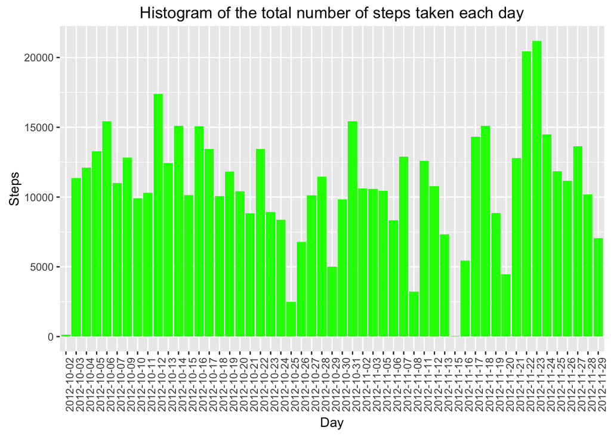

## Calculate the mean of the total number of steps taken per day

`## [1] 10766`

## Calculate the median of the total number of steps taken per day

```r
 medianFreq <- median(aggregate(steps~date,noNA, FUN=sum)$steps)
 medianFreq
```

```
## [1] 10765
```

## What is the average daily activity pattern

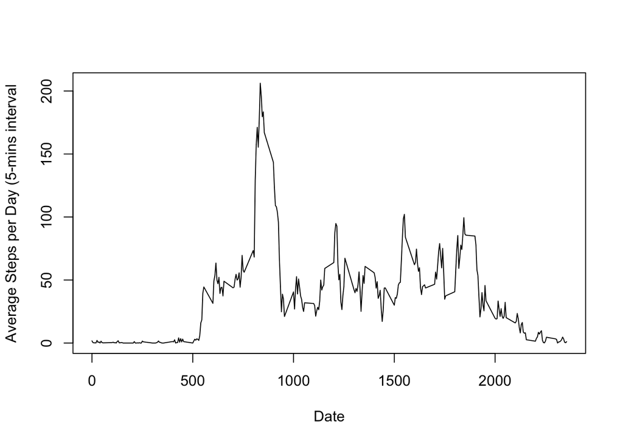

## Imputing missing values

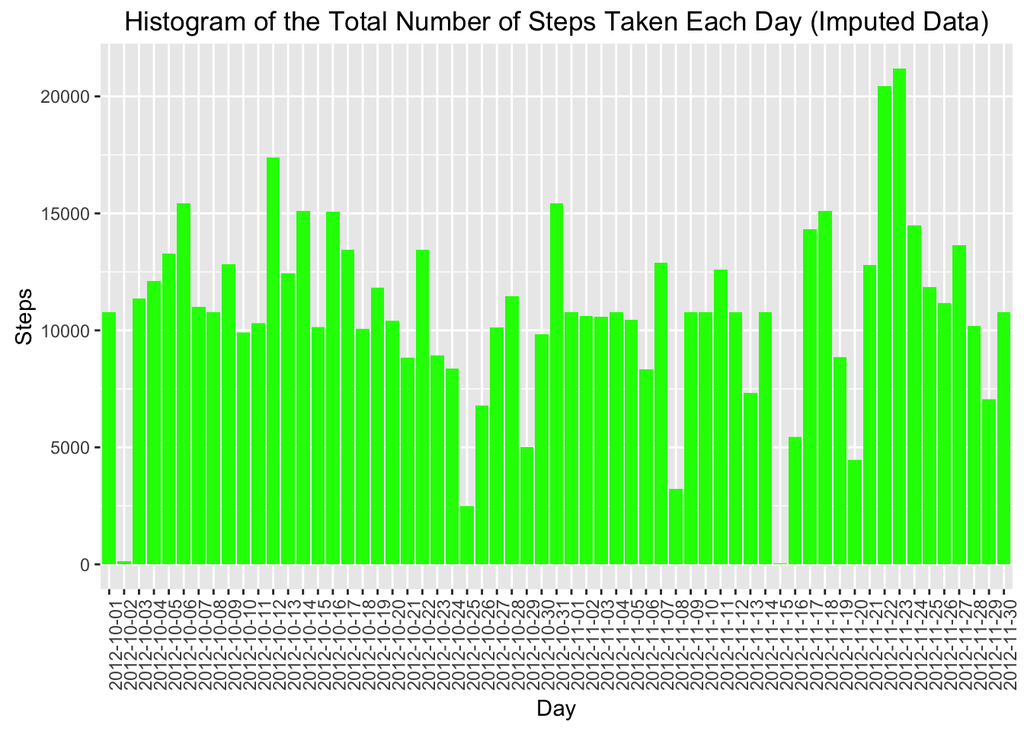

```r
numNA <- nrow(rawdata) - nrow(noNA)
imputedata <- rawdata
meanNA <- aggregate(steps~interval,imputedata, FUN=mean)
for(i in 1:nrow(imputedata)){
  if(is.na(imputedata[i,c("steps")])){
    imputedata[i,c("steps")] <- meanNA[meanNA$interval==imputedata[i,c("interval")], c("steps")]
  }
}
ggplot(imputedata,aes(as.factor(date),steps))+geom_bar(fill="green", stat="identity")+xlab("Day") + ylab("Steps")+ggtitle("Histogram of the Total Number of Steps Taken Each Day (Imputed Data)")+ theme(axis.text.x = element_text(angle = 90, hjust = 2))
```

## Calculate the mean and median total number of steps taken per day

```r
newmeanfreq <- as.integer(mean(aggregate(steps~date, imputedata, FUN = sum)$steps))
newmeanfreq
```

```
## [1] 10766
```

```r
newmedianfreq <- median(aggregate(steps~date, imputedata, FUN = sum)$steps)
newmedianfreq
```

```
## [1] 10766.19
```

# differences in activity patterns between weekdays and weekends

```r
weekDayEnd <- data.frame("dayType"=character(0))
weekDayEnd <- NULL

#Check wether the day is a weekday or weekend (Saturday)
weekInd <- function(day){
  if (weekdays(day)=="Saturday") {
    out <- "Weekend"
  } else {
    out <- "Weekday"
  }
  out
}

for (i in 1:nrow(imputedata)){
  date <- imputedata[i,c("date")]
  newObs <- data.frame("dayType"= weekInd(as.Date(date)))
  weekDayEnd <- rbind(weekDayEnd, newObs)
}
```

# Add the day type column in the data set

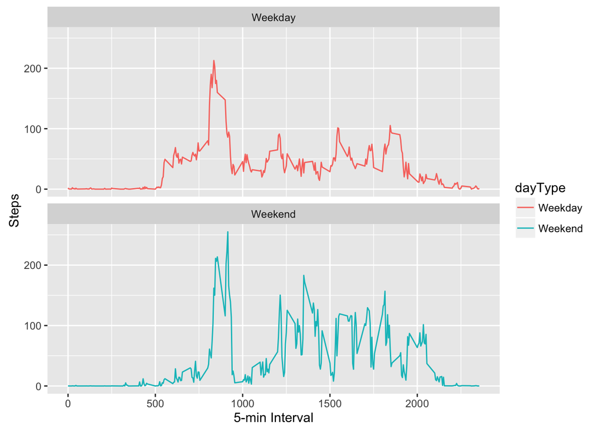

```r
imputedata <- cbind(imputedata, weekDayEnd)
averageWeekDayEnd<-aggregate(steps~interval + dayType, imputedata, FUN=mean)
ggplot(averageWeekDayEnd,aes(interval,steps, color=dayType))+geom_line()+facet_wrap(~dayType, ncol=1)+xlab("5-min Interval")+ylab("Steps")+guides(fill=FALSE)
```